# Ensemble_Project

```python
#import the necessary libraries
import warnings
warnings.filterwarnings('ignore')

import pandas as pd
import numpy as np
import seaborn as sns
import matplotlib.pyplot as plt
%matplotlib inline

import math

# Feature Engineering
from sklearn.preprocessing import LabelEncoder, StandardScaler
# Sample and parameter tuning
from sklearn.model_selection import train_test_split, GridSearchCV

#Predictive Modeling
from sklearn.svm import SVC
from sklearn.naive_bayes import GaussianNB
from sklearn.tree import DecisionTreeClassifier
from sklearn.neighbors import KNeighborsClassifier
from sklearn.linear_model import LogisticRegression, SGDClassifier
from sklearn.ensemble import BaggingClassifier, AdaBoostClassifier, GradientBoostingClassifier, RandomForestClassifier

# Evaluation metrics
from sklearn.metrics import confusion_matrix, classification_report, roc_curve, auc, accuracy_score, precision_recall_curve
```

```python
#read the data as dataframe and check if it is loaded
data = pd.read_csv('bank-full.csv')
data.head()
```

|  | age | job | marital | education | default | balance | housing | loan | contact | day | month | duration | campaign | pdays | previous | poutcome | Target |
| --- | --- | --- | --- | --- | --- | --- | --- | --- | --- | --- | --- | --- | --- | --- | --- | --- | --- |
| 0 | 58 | management | married | tertiary | no | 2143 | yes | no | unknown | 5 | may | 261 | 1 | -1 | 0 | unknown | no |
| 1 | 44 | technician | single | secondary | no | 29 | yes | no | unknown | 5 | may | 151 | 1 | -1 | 0 | unknown | no |
| 2 | 33 | entrepreneur | married | secondary | no | 2 | yes | yes | unknown | 5 | may | 76 | 1 | -1 | 0 | unknown | no |
| 3 | 47 | blue-collar | married | unknown | no | 1506 | yes | no | unknown | 5 | may | 92 | 1 | -1 | 0 | unknown | no |
| 4 | 33 | unknown | single | unknown | no | 1 | no | no | unknown | 5 | may | 198 | 1 | -1 | 0 | unknown | no |

```python
#basic EDA
data.shape
```

```
(45211, 17)
```

The given data has 45211 rows and 17 columns.

```python
data.info()
```

```
<class 'pandas.core.frame.DataFrame'>
RangeIndex: 45211 entries, 0 to 45210
Data columns (total 17 columns):
age          45211 non-null int64
job          45211 non-null object
marital      45211 non-null object
education    45211 non-null object
default      45211 non-null object
balance      45211 non-null int64
housing      45211 non-null object
loan         45211 non-null object
contact      45211 non-null object
day          45211 non-null int64
month        45211 non-null object
duration     45211 non-null int64
campaign     45211 non-null int64
pdays        45211 non-null int64
previous     45211 non-null int64
poutcome     45211 non-null object
Target       45211 non-null object
dtypes: int64(7), object(10)
memory usage: 5.9+ MB
```

Of the 17 columns, Age,Balance,Day,Duration, Campaign,Pdays,Previous are numerical attributes of integer typr and the rest of the columns are categorical data.

```python
# List the numerical and categorical columns
numeric_cols = data.select_dtypes(include=[np.number]).columns.tolist()
categ_cols = data.select_dtypes(include=[np.object]).columns.tolist()
print('The numeric attributes are:', numeric_cols)
print('The categorical attributes are:', categ_cols)
```

```
The numeric attributes are: ['age', 'balance', 'day', 'duration', 'campaign', 'pdays', 'previous']
The categorical attributes are: ['job', 'marital', 'education', 'default', 'housing', 'loan', 'contact', 'month', 'poutcome', 'Target']
```

```python
for cols in categ_cols:
    print('Unique values for', cols, 'is:',data[cols].unique())
```

```
Unique values for job is: ['management' 'technician' 'entrepreneur' 'blue-collar' 'unknown'
 'retired' 'admin.' 'services' 'self-employed' 'unemployed' 'housemaid'
 'student']
Unique values for marital is: ['married' 'single' 'divorced']
Unique values for education is: ['tertiary' 'secondary' 'unknown' 'primary']
Unique values for default is: ['no' 'yes']
Unique values for housing is: ['yes' 'no']
Unique values for loan is: ['no' 'yes']
Unique values for contact is: ['unknown' 'cellular' 'telephone']
Unique values for month is: ['may' 'jun' 'jul' 'aug' 'oct' 'nov' 'dec' 'jan' 'feb' 'mar' 'apr' 'sep']
Unique values for poutcome is: ['unknown' 'failure' 'other' 'success']
Unique values for Target is: ['no' 'yes']
```

```python
# Checking for null values
data.isnull().sum()
```

```
age          0
job          0
marital      0
education    0
default      0
balance      0
housing      0
loan         0
contact      0
day          0
month        0
duration     0
campaign     0
pdays        0
previous     0
poutcome     0
Target       0
dtype: int64
```

There are no null values

```python
#checking for duplicates
data.duplicated().any()
```

```
False
```

```python
data.describe().T
```

|  | count | mean | std | min | 25% | 50% | 75% | max |
| --- | --- | --- | --- | --- | --- | --- | --- | --- |
| age | 45211.0 | 40.936210 | 10.618762 | 18.0 | 33.0 | 39.0 | 48.0 | 95.0 |
| balance | 45211.0 | 1362.272058 | 3044.765829 | -8019.0 | 72.0 | 448.0 | 1428.0 | 102127.0 |
| day | 45211.0 | 15.806419 | 8.322476 | 1.0 | 8.0 | 16.0 | 21.0 | 31.0 |
| duration | 45211.0 | 258.163080 | 257.527812 | 0.0 | 103.0 | 180.0 | 319.0 | 4918.0 |
| campaign | 45211.0 | 2.763841 | 3.098021 | 1.0 | 1.0 | 2.0 | 3.0 | 63.0 |
| pdays | 45211.0 | 40.197828 | 100.128746 | -1.0 | -1.0 | -1.0 | -1.0 | 871.0 |
| previous | 45211.0 | 0.580323 | 2.303441 | 0.0 | 0.0 | 0.0 | 0.0 | 275.0 |

Observations:

Age columns has a minimum of 18 and maximum of 95 value which indicates the campaign covers a wide age group of clients. Balance column indicates there are clients whose bank balance is in negative as well. Day column has a min of 1, max of 31 and mean of 15 which clearly shows that the data covers every day in a month, there is no exceptions. Maximum value of duration column indicates clients were contacted for more than 80 mins in a single call. There are extreme outliers in the campaign and previous columns. Negative sign in the pdays column indicates there are clients who were not previously contacted

```python
data.describe(include='object').T
```

|  | count | unique | top | freq |
| --- | --- | --- | --- | --- |
| job | 45211 | 12 | blue-collar | 9732 |
| marital | 45211 | 3 | married | 27214 |
| education | 45211 | 4 | secondary | 23202 |
| default | 45211 | 2 | no | 44396 |
| housing | 45211 | 2 | yes | 25130 |
| loan | 45211 | 2 | no | 37967 |
| contact | 45211 | 3 | cellular | 29285 |
| month | 45211 | 12 | may | 13766 |
| poutcome | 45211 | 4 | unknown | 36959 |
| Target | 45211 | 2 | no | 39922 |

```python
##Checking the distribution of target variable
```

```python
display(data['Target'].value_counts(), data['Target'].value_counts(normalize = True)*100)
```

```
no     39922
yes     5289
Name: Target, dtype: int64
```

```
no     88.30152
yes    11.69848
Name: Target, dtype: float64
```

Out of 45211 cases, only 5289 (=11.69%) are the cases where the client has subscribed to the term deposit. This indicates a highly unbalanced data set.

```python
##Univariate Analysis
```

Let's explore the spread of data points or the observations for each independent attribute. We will be using the density curve plus histogram and boxplot for numerical features and count plot for discrete features.

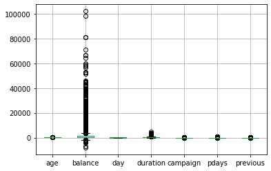

```python
#checking for the presence of outliers
data.boxplot()
plt.show()
```

Age, balance, duration, campaign, pdays and previous have outliers. Outliers can be handled by handled by rescaling the data during training or by using Z scores

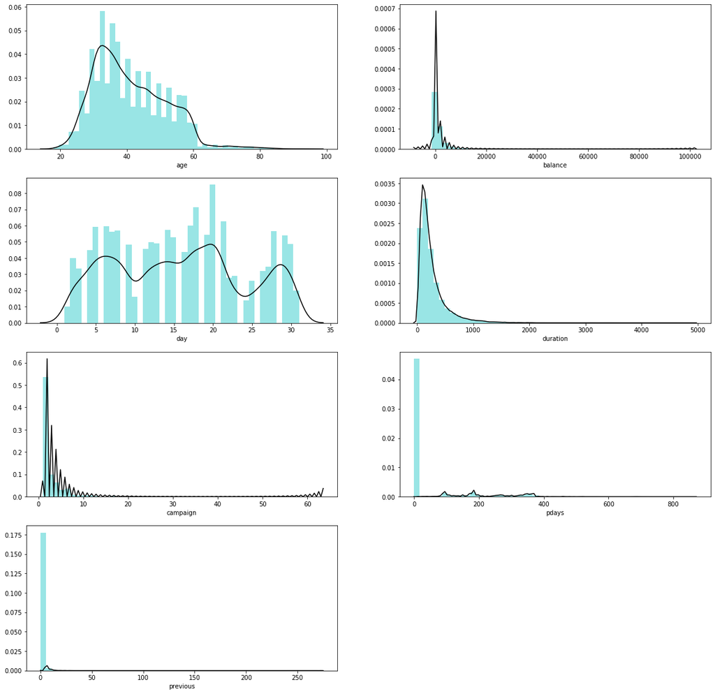

```python
# Check for distribution skewness
plt.figure(figsize=(20,20))
index = 1
for col in numeric_cols:
    plt.subplot(round(len(numeric_cols) / 2), 2, index)
    sns.distplot(data[col], kde_kws={"color": "k"}, hist_kws={"color": "c"})
    index += 1
```

none of the variables are normal in nature so using median as a imputation will suffice. seems balance, campaign, duration and pdays are following poisson distribution

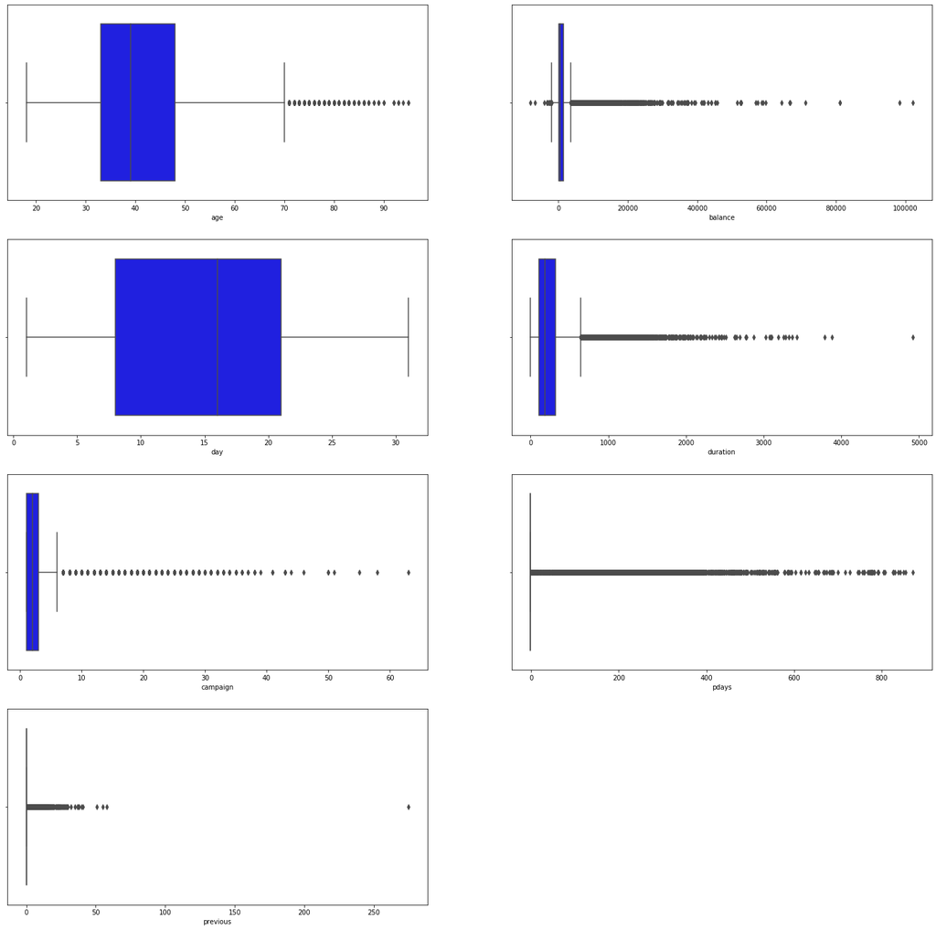

```python
# Check the distribution Central Tendency
plt.figure(figsize=(25,25))
index = 1
for col in numeric_cols:
    plt.subplot(round(len(numeric_cols) / 2), 2, index)
    sns.boxplot(data[col], color='blue')
    index += 1
```

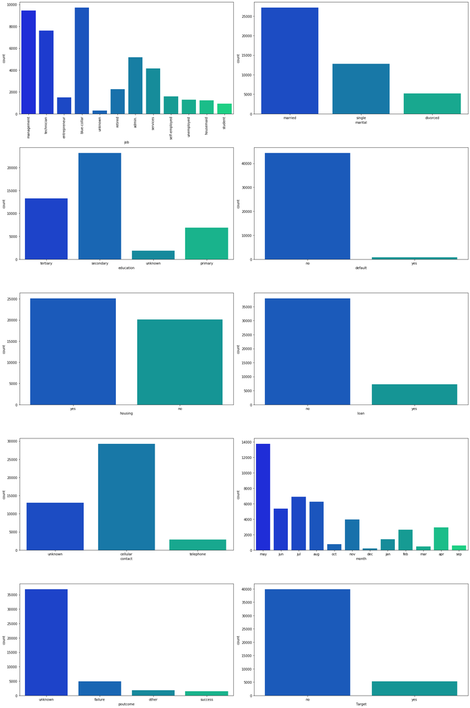

```python
# Check the frequency inside each categorical features
plt.figure(figsize=(20,30))
index = 1
for col in categ_cols:
    plt.subplot(round(len(categ_cols) / 2), 2, index)
    sns.countplot(col, data=data, palette='winter')
    if col == 'job':
        plt.xticks(rotation='vertical')
    index += 1
plt.tight_layout()
```

```python
##Bivariate Analysis
```

Let's explore the relationship among the predictor variables and between the predictor variables and target column. We will be using the density curve plus histogram, boxplot and pairplots

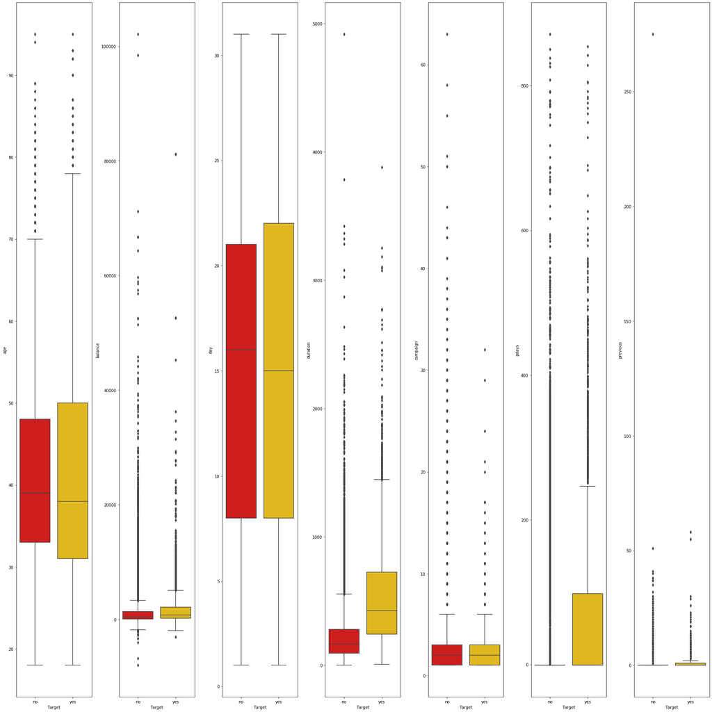

```python
# Check the distribution Central Tendency for different Outcomes
plt.figure(figsize=(25,25))
index = 1
for col in numeric_cols:
    plt.subplot(1, len(numeric_cols), index)
    sns.boxplot(data.Target, data[col], palette='hot')
    index += 1
plt.tight_layout()
```

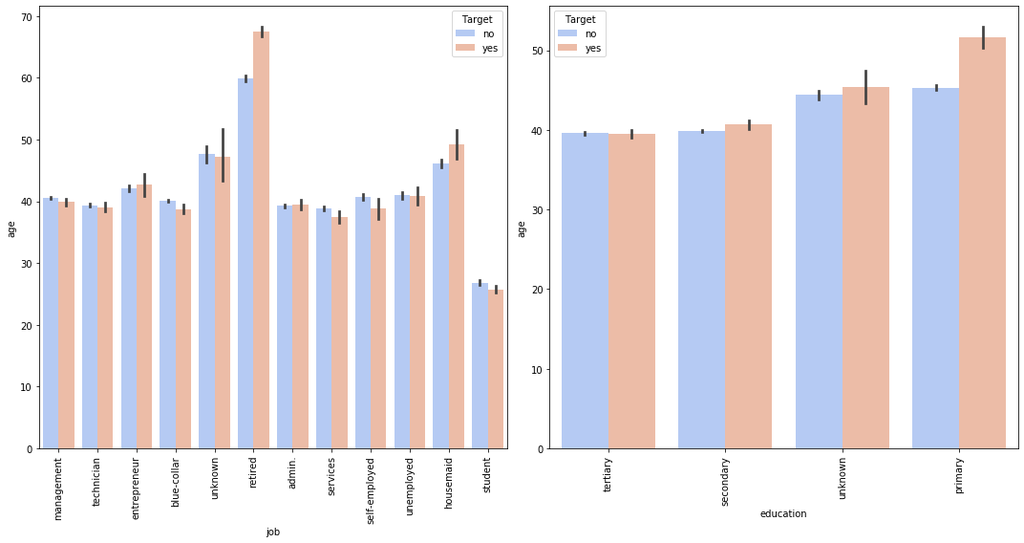

```python
# Check the distribution Central Tendency for different Outcomes
plt.figure(figsize=(15,8))
index = 1
for col in ['job', 'education']:
    plt.subplot(1, 2, index)
    sns.barplot(data[col], data.age, data.Target, palette='coolwarm')
    plt.xticks(rotation='vertical')
    index += 1
plt.tight_layout()
```

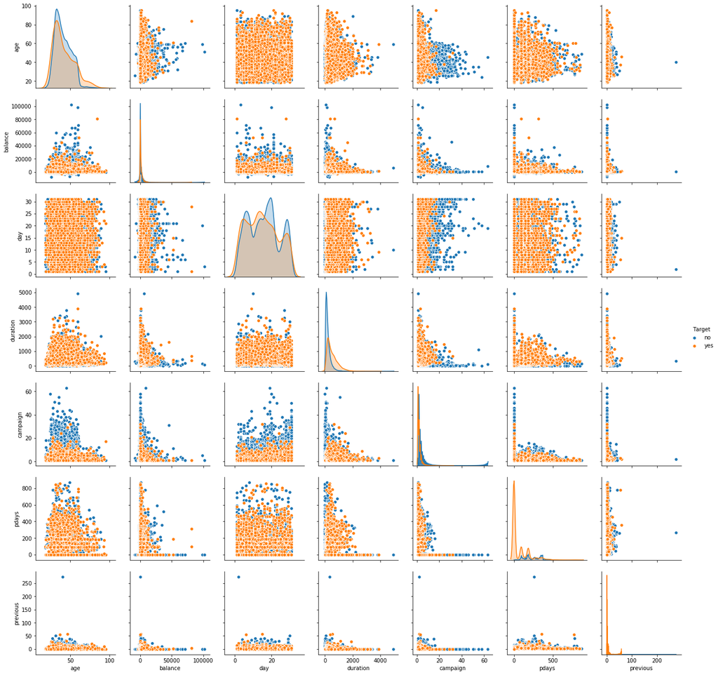

```python
sns.pairplot(data, diag_kind='kde', hue="Target")
plt.show()
```

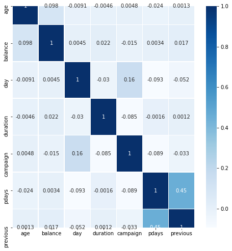

```python
# Visualize the correlation matrix
plt.figure(figsize=(8,8))
sns.heatmap(data.corr(), annot=True, cmap='Blues', linewidths=0.5)
```

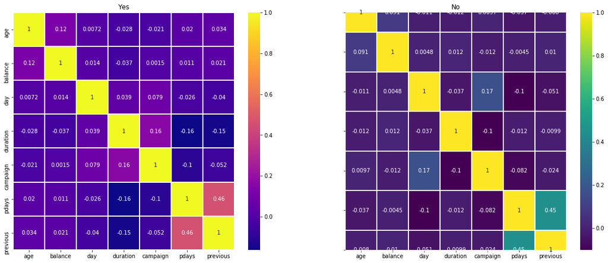

```python
# Visualize the correlation matrix in each Outcomes category
f, axes = plt.subplots(ncols=2, sharey=True, figsize=(20,8))
axes[0].set_title('Yes')
sns.heatmap(data[data.Target == 'yes'].iloc[:,:-1].corr(), annot=True, cmap='plasma', linewidths=1, ax=axes[0])
axes[1].set_title('No')
sns.heatmap(data[data.Target == 'no'].iloc[:,:-1].corr(), annot=True, cmap='viridis', linewidths=1, ax=axes[1])
```

```python
##Prepare the data to train a model
##LabelEncode the categorical variables
```

LabelEncoder() encodes labels with a value between 0 and (n-1) where n is the number of distinct labels in a column. If a label repeats, it assigns the same value to it as assigned earlier.

```python
# Convert all the categorical columns to numerical
le = LabelEncoder()
for col in categ_cols:
    data[col] = le.fit_transform(data[col])
    print(f'{col}:', dict(zip(le.classes_, range(len(le.classes_)))))

print()
data.info()
```

```
job: {'admin.': 0, 'blue-collar': 1, 'entrepreneur': 2, 'housemaid': 3, 'management': 4, 'retired': 5, 'self-employed': 6, 'services': 7, 'student': 8, 'technician': 9, 'unemployed': 10, 'unknown': 11}
marital: {'divorced': 0, 'married': 1, 'single': 2}
education: {'primary': 0, 'secondary': 1, 'tertiary': 2, 'unknown': 3}
default: {'no': 0, 'yes': 1}
housing: {'no': 0, 'yes': 1}
loan: {'no': 0, 'yes': 1}
contact: {'cellular': 0, 'telephone': 1, 'unknown': 2}
month: {'apr': 0, 'aug': 1, 'dec': 2, 'feb': 3, 'jan': 4, 'jul': 5, 'jun': 6, 'mar': 7, 'may': 8, 'nov': 9, 'oct': 10, 'sep': 11}
poutcome: {'failure': 0, 'other': 1, 'success': 2, 'unknown': 3}
Target: {'no': 0, 'yes': 1}

<class 'pandas.core.frame.DataFrame'>
RangeIndex: 45211 entries, 0 to 45210
Data columns (total 17 columns):
age          45211 non-null int64
job          45211 non-null int32
marital      45211 non-null int32
education    45211 non-null int32
default      45211 non-null int32
balance      45211 non-null int64
housing      45211 non-null int32
loan         45211 non-null int32
contact      45211 non-null int32
day          45211 non-null int64
month        45211 non-null int32
duration     45211 non-null int64
campaign     45211 non-null int64
pdays        45211 non-null int64
previous     45211 non-null int64
poutcome     45211 non-null int32
Target       45211 non-null int32
dtypes: int32(10), int64(7)
memory usage: 4.1 MB
```

Feature Scaling: Algorithms that exploit distances or similarities between data samples, such as k-NN and SVM, are sensitive to scale of the features. StandardScaler() will normalize the features so that each column/feature/variable will have mean = 0 and standard deviation = 1.

```python
X = data.drop('Target', axis=1)
y = data.Target
sc = StandardScaler()
X_scaled = sc.fit_transform(X)
X_scaled = pd.DataFrame(X_scaled, columns=X.columns)
X_scaled.head()
```

|  | age | job | marital | education | default | balance | housing | loan | contact | day | month | duration | campaign | pdays | previous | poutcome |
| --- | --- | --- | --- | --- | --- | --- | --- | --- | --- | --- | --- | --- | --- | --- | --- | --- |
| 0 | 1.606965 | -0.103820 | -0.275762 | 1.036362 | -0.13549 | 0.256419 | 0.893915 | -0.436803 | 1.514306 | -1.298476 | 0.823773 | 0.011016 | -0.569351 | -0.411453 | -0.25194 | 0.444898 |
| 1 | 0.288529 | 1.424008 | 1.368372 | -0.300556 | -0.13549 | -0.437895 | 0.893915 | -0.436803 | 1.514306 | -1.298476 | 0.823773 | -0.416127 | -0.569351 | -0.411453 | -0.25194 | 0.444898 |
| 2 | -0.747384 | -0.714951 | -0.275762 | -0.300556 | -0.13549 | -0.446762 | 0.893915 | 2.289359 | 1.514306 | -1.298476 | 0.823773 | -0.707361 | -0.569351 | -0.411453 | -0.25194 | 0.444898 |
| 3 | 0.571051 | -1.020516 | -0.275762 | 2.373280 | -0.13549 | 0.047205 | 0.893915 | -0.436803 | 1.514306 | -1.298476 | 0.823773 | -0.645231 | -0.569351 | -0.411453 | -0.25194 | 0.444898 |
| 4 | -0.747384 | 2.035139 | 1.368372 | 2.373280 | -0.13549 | -0.447091 | -1.118674 | -0.436803 | 1.514306 | -1.298476 | 0.823773 | -0.233620 | -0.569351 | -0.411453 | -0.25194 | 0.444898 |

Sample spliting: Divide the dataset into train-test in a ratio of 70:30 for training set and test set

```python
X_train, X_test, y_train, y_test = train_test_split(X_scaled, y, test_size=0.3, random_state=1)
X_train.shape, X_test.shape, y_train.shape, y_test.shape
```

```
((31647, 16), (13564, 16), (31647,), (13564,))
```

Training the Algorithms: Non-Ensemble Classifiers: We will first run the below regularized classfiers, not from ensemble family separately one after another and check which algorithm performs better and is a good candidate to be a week estimator for ensembling.

Logistic Regression Gaussian Naive Bayes Support Vector Machine K-Nearest Neighbors Stochastic Gradient Descent Decision Tree

```python
# A generic class to log the time taken
#Utilities
from time import time
class Timer():
    '''
    A generic class to log the time
    '''
    def __init__(self):
        self.start_ts = None
    def start(self):
        self.start_ts = time()
    def stop(self):
        return 'Time taken: %2fs' % (time()-self.start_ts)

timer = Timer()
```

```python
# A method that plots the Precision-Recall curve
def plot_prec_recall_vs_thresh(precisions, recalls, thresholds):
    plt.figure(figsize=(10,5))
    plt.plot(thresholds, precisions[:-1], 'b--', label='precision')
    plt.plot(thresholds, recalls[:-1], 'g--', label = 'recall')
    plt.xlabel('Threshold')
    plt.legend()
```

```python
# Let's create a generic method to train and test the model
def run_classification(estimator, X_train, X_test, y_train, y_test, prec_rcl=True):
    timer.start()
    # train the model
    clf = estimator.fit(X_train, y_train)
    # predict from the claffier
    y_pred = clf.predict(X_test)
    print('Estimator:', clf)
    print('='*80)
    print('Training accuracy: %.2f%%' % (accuracy_score(y_train, clf.predict(X_train)) * 100))
    print('Testing accuracy: %.2f%%' % (accuracy_score(y_test, y_pred) * 100))
    print('='*80)
    print('Confusion matrix:\n %s' % (confusion_matrix(y_test, y_pred)))
    print('='*80)
    print('Classification report:\n %s' % (classification_report(y_test, y_pred)))
    print(timer.stop(), 'to run the model')
    if prec_rcl:
        print('='*80)
        print('Precision-Recall curve of "Yes" records')
        # predict probabilities
        y_proba = clf.predict_proba(X_test)
        # keep probabilities for the positive outcome only  probs[:, 1]
        precision, recall, thresholds = precision_recall_curve(y_test,  y_proba[:, 1])
        plot_prec_recall_vs_thresh(precision, recall, thresholds)
```

```python
##Logistic regression:
```

```python
# Run generic Classification method for Logistic Regression
run_classification(LogisticRegression(penalty='l2', C=0.5),
                   X_train, X_test, y_train, y_test, False)
```

```
Estimator: LogisticRegression(C=0.5, class_weight=None, dual=False, fit_intercept=True,
                   intercept_scaling=1, l1_ratio=None, max_iter=100,
                   multi_class='auto', n_jobs=None, penalty='l2',
                   random_state=None, solver='lbfgs', tol=0.0001, verbose=0,
                   warm_start=False)
================================================================================
Training accuracy: 89.11%
Testing accuracy: 89.12%
================================================================================
Confusion matrix:
 [[11760   253]
 [ 1223   328]]
================================================================================
Classification report:
               precision    recall  f1-score   support

           0       0.91      0.98      0.94     12013
           1       0.56      0.21      0.31      1551

    accuracy                           0.89     13564
   macro avg       0.74      0.60      0.62     13564
weighted avg       0.87      0.89      0.87     13564

Time taken: 0.578033s to run the model
```

```python
## Gaussian Naive Bayes Classifier
```

```
Estimator: GaussianNB(priors=None, var_smoothing=1e-09)
================================================================================
Training accuracy: 83.46%
Testing accuracy: 83.48%
================================================================================
Confusion matrix:
 [[10578  1435]
 [  806   745]]
================================================================================
Classification report:
               precision    recall  f1-score   support

           0       0.93      0.88      0.90     12013
           1       0.34      0.48      0.40      1551

    accuracy                           0.83     13564
   macro avg       0.64      0.68      0.65     13564
weighted avg       0.86      0.83      0.85     13564

Time taken: 0.181209s to run the model
================================================================================
Precision-Recall curve of "Yes" records
```

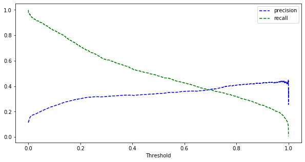

```python
# Run Classification for Gaussian Naive Bayes Classifier
run_classification(GaussianNB(),
                   X_train, X_test, y_train, y_test)
```

```python
##SVM
```

```python
# Run Classification for Support Vector Classifier
run_classification(SVC(C= 1, kernel='rbf', gamma= 1),
                   X_train, X_test, y_train, y_test, False)
```

```
Estimator: SVC(C=1, break_ties=False, cache_size=200, class_weight=None, coef0=0.0,
    decision_function_shape='ovr', degree=3, gamma=1, kernel='rbf', max_iter=-1,
    probability=False, random_state=None, shrinking=True, tol=0.001,
    verbose=False)
================================================================================
Training accuracy: 97.34%
Testing accuracy: 88.88%
================================================================================
Confusion matrix:
 [[11942    71]
 [ 1437   114]]
================================================================================
Classification report:
               precision    recall  f1-score   support

           0       0.89      0.99      0.94     12013
           1       0.62      0.07      0.13      1551

    accuracy                           0.89     13564
   macro avg       0.75      0.53      0.54     13564
weighted avg       0.86      0.89      0.85     13564

Time taken: 360.211337s to run the model
```

```python
##KNN
```

```
Estimator: KNeighborsClassifier(algorithm='auto', leaf_size=30, metric='minkowski',
                     metric_params=None, n_jobs=None, n_neighbors=5, p=2,
                     weights='uniform')
================================================================================
Training accuracy: 91.70%
Testing accuracy: 89.93%
================================================================================
Confusion matrix:
 [[11672   341]
 [ 1025   526]]
================================================================================
Classification report:
               precision    recall  f1-score   support

           0       0.92      0.97      0.94     12013
           1       0.61      0.34      0.44      1551

    accuracy                           0.90     13564
   macro avg       0.76      0.66      0.69     13564
weighted avg       0.88      0.90      0.89     13564

Time taken: 69.069771s to run the model
================================================================================
Precision-Recall curve of "Yes" records
```

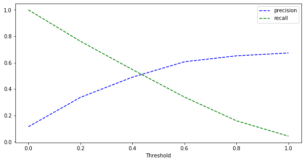

```python
# Run Classification for K-nearest neighbors Classifier
run_classification(KNeighborsClassifier(n_neighbors=5),
                   X_train, X_test, y_train, y_test)
```

```python
##Stochastic Gradient Descent
```

```
Estimator: SGDClassifier(alpha=0.001, average=False, class_weight=None,
              early_stopping=False, epsilon=0.1, eta0=0.0, fit_intercept=True,
              l1_ratio=1, learning_rate='optimal', loss='log', max_iter=1000,
              n_iter_no_change=5, n_jobs=None, penalty='l2', power_t=0.5,
              random_state=None, shuffle=True, tol=0.001,
              validation_fraction=0.1, verbose=0, warm_start=False)
================================================================================
Training accuracy: 89.16%
Testing accuracy: 89.13%
================================================================================
Confusion matrix:
 [[11715   298]
 [ 1176   375]]
================================================================================
Classification report:
               precision    recall  f1-score   support

           0       0.91      0.98      0.94     12013
           1       0.56      0.24      0.34      1551

    accuracy                           0.89     13564
   macro avg       0.73      0.61      0.64     13564
weighted avg       0.87      0.89      0.87     13564

Time taken: 0.287409s to run the model
================================================================================
Precision-Recall curve of "Yes" records
```

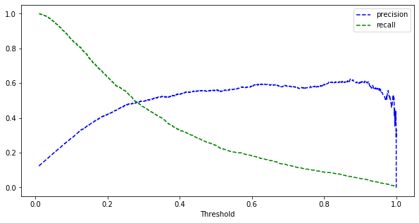

```python
# Run Classification for Stochastic Gradient Descent Classifier
run_classification(SGDClassifier(loss='log', alpha=0.001, l1_ratio=1),
                   X_train, X_test, y_train, y_test)
```

```python
##Decision Tree Classifier
```

```
Estimator: DecisionTreeClassifier(ccp_alpha=0.0, class_weight=None, criterion='gini',
                       max_depth=7, max_features=None, max_leaf_nodes=None,
                       min_impurity_decrease=0.0, min_impurity_split=None,
                       min_samples_leaf=1, min_samples_split=2,
                       min_weight_fraction_leaf=0.0, presort='deprecated',
                       random_state=None, splitter='best')
================================================================================
Training accuracy: 91.09%
Testing accuracy: 89.86%
================================================================================
Confusion matrix:
 [[11592   421]
 [  954   597]]
================================================================================
Classification report:
               precision    recall  f1-score   support

           0       0.92      0.96      0.94     12013
           1       0.59      0.38      0.46      1551

    accuracy                           0.90     13564
   macro avg       0.76      0.67      0.70     13564
weighted avg       0.89      0.90      0.89     13564

Time taken: 0.366004s to run the model
================================================================================
Precision-Recall curve of "Yes" records
```

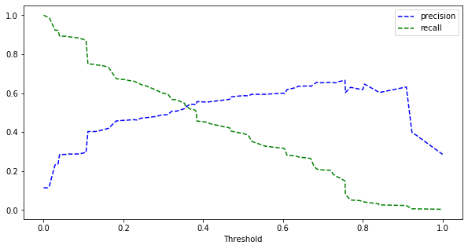

```python
# Run Classification for Decision Tree Classifier
run_classification(DecisionTreeClassifier(criterion='gini', max_depth=7),
                   X_train, X_test, y_train, y_test)
```

```python
##Ensemble Techniques
```

Bagging: Bagging or Bootstrap Aggregating is an ensembling algorithm that can be used for both classification (BaggingClassifier) and regression (BaggingRegressor) problems. It follows the typical bagging technique to make predictions. Decision Tree is used as the default base estimator unless specified otherwise. Following are the steps for the bagging meta-estimator algorithm:

Random subsets are created from the original dataset (Bootstrapping). The subset of the dataset includes all features. A user-specified base estimator is fitted on each of these smaller sets. Predictions from each model are combined to get the final result.

```
Estimator: BaggingClassifier(base_estimator=None, bootstrap=True, bootstrap_features=False,
                  max_features=1.0, max_samples=1.0, n_estimators=10,
                  n_jobs=None, oob_score=False, random_state=None, verbose=0,
                  warm_start=False)
================================================================================
Training accuracy: 99.22%
Testing accuracy: 89.97%
================================================================================
Confusion matrix:
 [[11556   457]
 [  903   648]]
================================================================================
Classification report:
               precision    recall  f1-score   support

           0       0.93      0.96      0.94     12013
           1       0.59      0.42      0.49      1551

    accuracy                           0.90     13564
   macro avg       0.76      0.69      0.72     13564
weighted avg       0.89      0.90      0.89     13564

Time taken: 2.963639s to run the model
================================================================================
Precision-Recall curve of "Yes" records
```

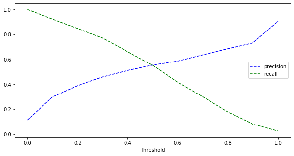

```python
run_classification(BaggingClassifier(),
                   X_train, X_test, y_train, y_test)
```

```python
##Adaptive Boosting
```

```
Estimator: AdaBoostClassifier(algorithm='SAMME.R', base_estimator=None, learning_rate=1.0,
                   n_estimators=50, random_state=None)
================================================================================
Training accuracy: 89.86%
Testing accuracy: 89.85%
================================================================================
Confusion matrix:
 [[11673   340]
 [ 1037   514]]
================================================================================
Classification report:
               precision    recall  f1-score   support

           0       0.92      0.97      0.94     12013
           1       0.60      0.33      0.43      1551

    accuracy                           0.90     13564
   macro avg       0.76      0.65      0.69     13564
weighted avg       0.88      0.90      0.89     13564

Time taken: 3.608818s to run the model
================================================================================
Precision-Recall curve of "Yes" records
```

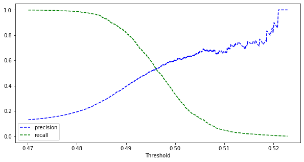

```python
run_classification(AdaBoostClassifier(),
                   X_train, X_test, y_train, y_test)
```

```python
##Random Forest
```

```
Estimator: RandomForestClassifier(bootstrap=True, ccp_alpha=0.0, class_weight=None,
                       criterion='gini', max_depth=None, max_features='auto',
                       max_leaf_nodes=None, max_samples=None,
                       min_impurity_decrease=0.0, min_impurity_split=None,
                       min_samples_leaf=1, min_samples_split=2,
                       min_weight_fraction_leaf=0.0, n_estimators=100,
                       n_jobs=None, oob_score=False, random_state=None,
                       verbose=0, warm_start=False)
================================================================================
Training accuracy: 100.00%
Testing accuracy: 90.64%
================================================================================
Confusion matrix:
 [[11618   395]
 [  875   676]]
================================================================================
Classification report:
               precision    recall  f1-score   support

           0       0.93      0.97      0.95     12013
           1       0.63      0.44      0.52      1551

    accuracy                           0.91     13564
   macro avg       0.78      0.70      0.73     13564
weighted avg       0.90      0.91      0.90     13564

Time taken: 10.415280s to run the model
================================================================================
Precision-Recall curve of "Yes" records
```

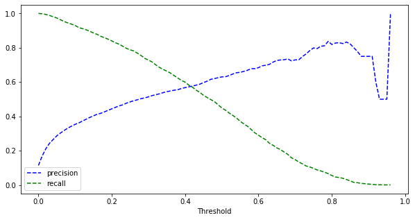

```python
run_classification(RandomForestClassifier(),
                   X_train, X_test, y_train, y_test)
```

```python
##Gradient Boosting Classifier (GBM)
```

```
Estimator: GradientBoostingClassifier(ccp_alpha=0.0, criterion='friedman_mse', init=None,
                           learning_rate=0.1, loss='deviance', max_depth=3,
                           max_features=None, max_leaf_nodes=None,
                           min_impurity_decrease=0.0, min_impurity_split=None,
                           min_samples_leaf=1, min_samples_split=2,
                           min_weight_fraction_leaf=0.0, n_estimators=100,
                           n_iter_no_change=None, presort='deprecated',
                           random_state=None, subsample=1.0, tol=0.0001,
                           validation_fraction=0.1, verbose=0,
                           warm_start=False)
================================================================================
Training accuracy: 91.03%
Testing accuracy: 90.28%
================================================================================
Confusion matrix:
 [[11648   365]
 [  953   598]]
================================================================================
Classification report:
               precision    recall  f1-score   support

           0       0.92      0.97      0.95     12013
           1       0.62      0.39      0.48      1551

    accuracy                           0.90     13564
   macro avg       0.77      0.68      0.71     13564
weighted avg       0.89      0.90      0.89     13564

Time taken: 7.890459s to run the model
================================================================================
Precision-Recall curve of "Yes" records
```

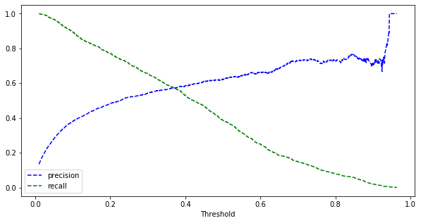

```python
run_classification(GradientBoostingClassifier(),
                   X_train, X_test, y_train, y_test)
```

Conclusion: Out of all algorithms, Random Forest Classifier has best performance. The test accuracy of Random Forest ensemble classifier is 90.64% which is best among all other ensemble techniques. Hence concluding this ensemble technique can be used to predict the potential client who can subscribe the Portugese Banks term deposit plan.